# Reproducible Research Project 1

# What is the average daily activity pattern?

# Time series plot of the average number of steps taken

```r
StepsPerInterval <- aggregate( steps ~ interval, activity, mean)
head(StepsPerInterval)
```

```
##   interval     steps
## 1        0 1.7169811
## 2        5 0.3396226
## 3       10 0.1320755
## 4       15 0.1509434
## 5       20 0.0754717
## 6       25 2.0943396
```

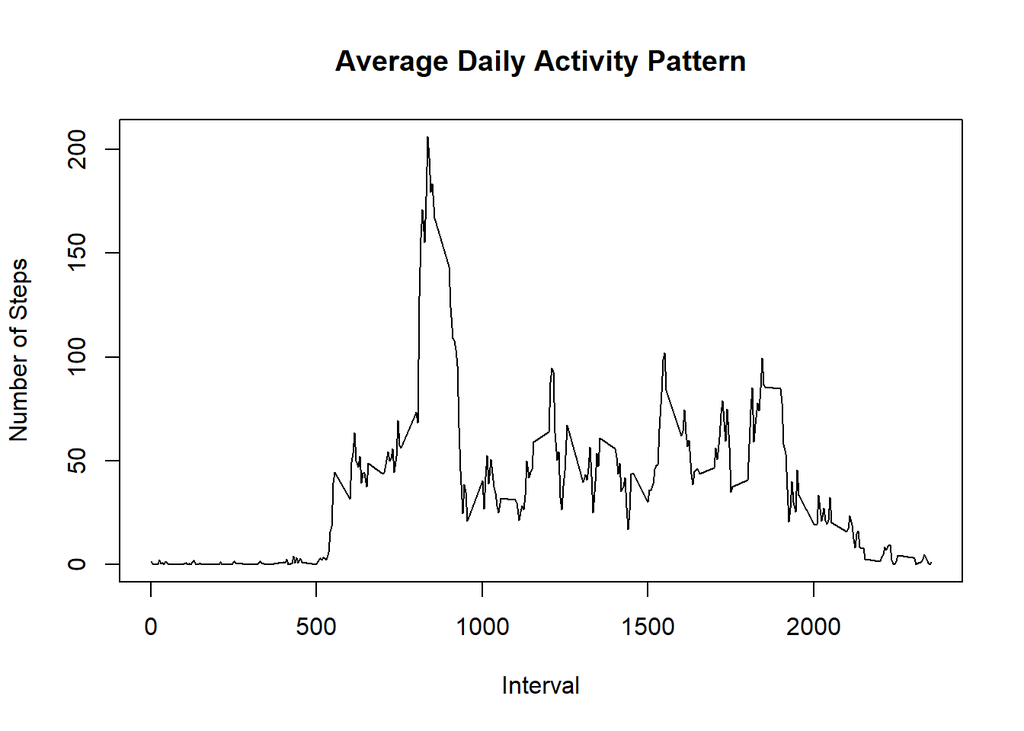

```r
plot(StepsPerInterval$interval,StepsPerInterval$steps, type="l", xlab="Interval", ylab="Number of Steps",main="Average Daily Activity Pattern")
```

# Which 5-minute interval, on average across all the days in the dataset, contains the maximum number of steps?

```r
MaxInt <- StepsPerInterval[which.max(StepsPerInterval$steps),1]
```

Interval

# 835

# Imputing missing values

There are a number of days/intervals where there are missing values (coded as NA). The presence of missing days may introduce bias into some calculations or summaries of the data.

# Calculate and report the total number of missing values in the dataset

```r
nmv <- length(which(is.na(activity$steps)))
```

There are

# 2304

values missing

For filling in all of the missing values in the dataset I decided to use the mean for that 5-minute interval. I will create new dataset that is equal to the original dataset but with the missing data filled in:

```r
newActivity <- transform(activity, steps = ifelse(is.na(activity$steps), StepsPerInterval$steps[match(activity$interval, StepsPerInterval$interval)],
activity$steps))
head(newActivity)
```

```
##       steps       date interval
## 1 1.7169811 2012-10-01        0
## 2 0.3396226 2012-10-01        5
## 3 0.1320755 2012-10-01       10
## 4 0.1509434 2012-10-01       15
## 5 0.0754717 2012-10-01       20
## 6 2.0943396 2012-10-01       25
```

Now let’s create a new histogram of the total number of steps taken each day. And then let’s calculate and report the mean and median total number of steps taken per day.

Once that is done we will be able to compare how these values differ from the estimates from the first dataset.

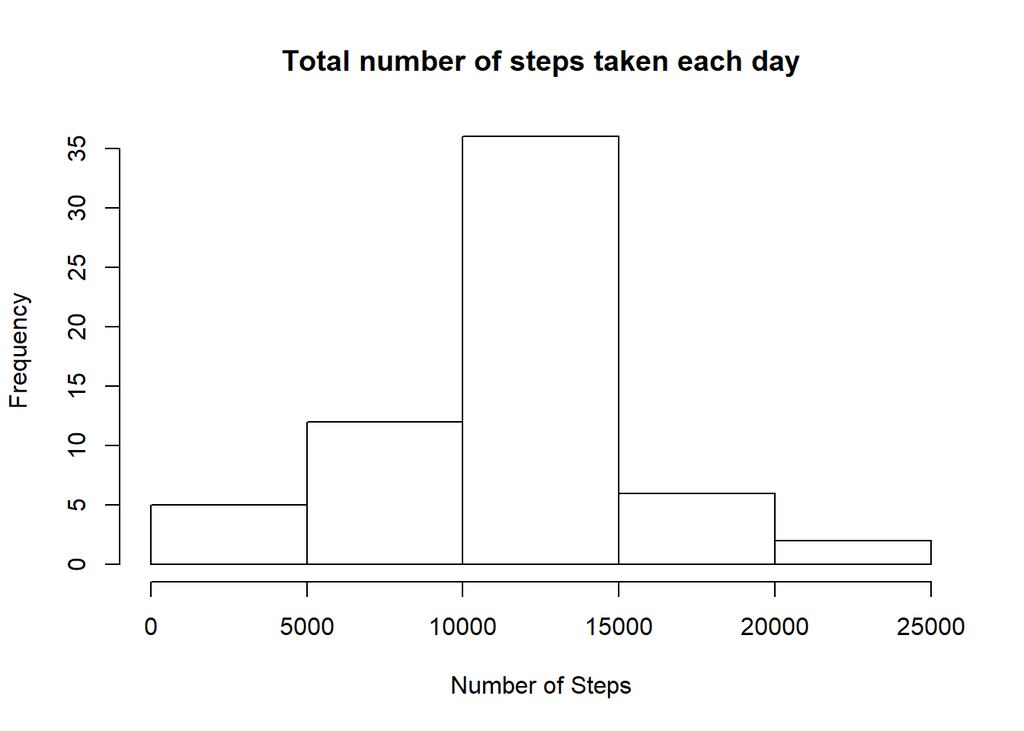

```r
NewStepsPerDay <- aggregate (steps ~ date, newActivity, sum)
hist (NewStepsPerDay$steps, main="Total number of steps taken each day",
      xlab="Number of Steps")
```

```r
newspdmean <- mean(NewStepsPerDay$steps)
newspdmedian <- median(NewStepsPerDay$steps)
diffspdmean <- newspdmean - spdmean
diffspdmedian <- newspdmedian - spdmedian
```

New dataset mean